# Reproducible Corpus Creation: Scraping and Transcribing Throne Speeches

Author

Doron Feingold

Published

August 19, 2025

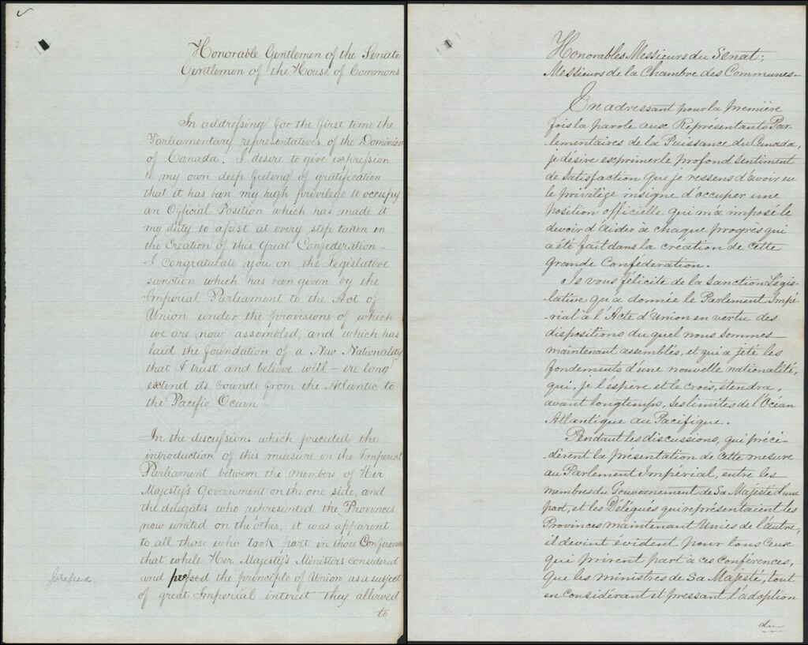

The first Canadian Speech from the Throne (1867)

## Overview

This document provides a complete, reproducible pipeline for creating a high-quality text corpus of Canadian Throne Speeches. The process involves scraping an index page from the Parliament of Canada website, programmatically processing downloadable PDFs using the Gemini 1.5 Vision model for high-quality OCR, and providing an interactive workflow to handle speeches that require manual extraction. The final output is a clean `throne_speeches` directory with text file for each speech, and a `speech_index.csv` file.

## Setup and Configuration

First, we load the required R packages and configure the environment. This includes securely loading the API key and defining all the helper functions we’ll need for scraping, transcribing, saving, and indexing the speeches.

### Libraries

```r
set.seed(1867)

# Required Libraries
library(rvest) # For web scraping
library(dplyr) # For data manipulation
library(stringr) # For text cleaning
library(httr2) # For API requests and downloads
library(pdftools) # To convert PDFs to images
library(jsonlite) # To handle JSON
library(base64enc) # To encode images
library(purrr) # For functional programming
library(readr) # For writing files
library(clipr) # For using save from clipboard
```

### API Key and Output Directory

```r
# --- API Key Configuration ---
# The API key is loaded securely from an environment variable.
GEMINI_API_KEY <- Sys.getenv("GEMINI_API_KEY")

# --- Define Output Directory ---
output_dir <- "output/throne_speeches_txt/"
if (!dir.exists(output_dir)) {
  dir.create(output_dir)
}
```